# Prosper Loan Exploratory Analysis

## by ODENIYI, Oluwasegun Olawale

- Introduction
- Data Wrangling
- Univariate Exploration
- Bivariate Exploration
- Multivariate Exploration
- Conclusions

## Introduction

This project is focused majorly on showcasing my visualization skills. The dataset for this project was provided by Udacity and downloaded from [here](https://s3.amazonaws.com/udacity-hosted-downloads/ud651/prosperLoanData.csv). It consists of records of Proper loans generated between the year 2005 - 2014. Investigating the key variables in this historical data will help to support the lending company in its decision-making, as well as discover areas that needs adjustment or attention. I find it interesting to be doing this analysis because money lending is a delicate business that requires careful approach on the part of the management, and also because borrowers are given the opportunity to borrow when they are not financiallly bouyant enough.

> For this analysis, **Bad Loans** refer to those loans that has been characterised as; defaulted, chargedoff, or past due.

This project was guided by the following questions in mind:

1. What are the factors that can predict the interest rate on loans?
2. What is the difference between loans based on on the Loan Original Amount?
3. What are the factors that can predict a loan's outcome?
4. Where do most of our customers come from?
5. Who are the customers that most successfully complete their loans?
6. Which month receives the most loans across the years?

## Preliminary Wrangling

### Gathering Data

```python
# import all packages and set plots to be embedded inline
import numpy as np
import pandas as pd
import matplotlib.pyplot as plt
import seaborn as sns

%matplotlib inline
```

```python
# Load the prosper loan dataset and store in a variable "loan_data"
loan_data= pd.read_csv('prosperLoanData.csv')
```

```python
# Set to display all columns for a better overview of the columns
pd.set_option('display.max_columns', None)

loan_data.head(50)
```

|  | ListingKey | ListingNumber | ListingCreationDate | CreditGrade | Term | LoanStatus | ClosedDate | BorrowerAPR | BorrowerRate | LenderYield | EstimatedEffectiveYield | EstimatedLoss | EstimatedReturn | ProsperRating (numeric) | ProsperRating (Alpha) | ProsperScore | ListingCategory (numeric) | BorrowerState | Occupation | EmploymentStatus | EmploymentStatusDuration | IsBorrowerHomeowner | CurrentlyInGroup | GroupKey | DateCreditPulled | CreditScoreRangeLower | CreditScoreRangeUpper | FirstRecordedCreditLine | CurrentCreditLines | … |
| --- | --- | --- | --- | --- | --- | --- | --- | --- | --- | --- | --- | --- | --- | --- | --- | --- | --- | --- | --- | --- | --- | --- | --- | --- | --- | --- | --- | --- | --- | --- |
| 0 | 1021339766868145413AB3B | 193129 | 2007-08-26 19:09:29.263000000 | C | 36 | Completed | 2009-08-14 00:00:00 | 0.16516 | 0.1580 | 0.1380 | NaN | NaN | NaN | NaN | NaN | NaN | 0 | CO | Other | Self-employed | 2.0 | True | True | NaN | 2007-08-26 18:41:46.780000000 | 640.0 | 659.0 | 2001-10-11 00:00:00 | 5.0 | … |
| 1 | 10273602499503308B223C1 | 1209647 | 2014-02-27 08:28:07.900000000 | NaN | 36 | Current | NaN | 0.12016 | 0.0920 | 0.0820 | 0.07960 | 0.0249 | 0.05470 | 6.0 | A | 7.0 | 2 | CO | Professional | Employed | 44.0 | False | False | NaN | 2014-02-27 08:28:14 | 680.0 | 699.0 | 1996-03-18 00:00:00 | 14.0 | … |
| 2 | 0EE9337825851032864889A | 81716 | 2007-01-05 15:00:47.090000000 | HR | 36 | Completed | 2009-12-17 00:00:00 | 0.28269 | 0.2750 | 0.2400 | NaN | NaN | NaN | NaN | NaN | NaN | 0 | GA | Other | Not available | NaN | False | True | 783C3371218786870A73D20 | 2007-01-02 14:09:10.060000000 | 480.0 | 499.0 | 2002-07-27 00:00:00 | NaN | … |
| 3 | 0EF5356002482715299901A | 658116 | 2012-10-22 11:02:35.010000000 | NaN | 36 | Current | NaN | 0.12528 | 0.0974 | 0.0874 | 0.08490 | 0.0249 | 0.06000 | 6.0 | A | 9.0 | 16 | GA | Skilled Labor | Employed | 113.0 | True | False | NaN | 2012-10-22 11:02:32 | 800.0 | 819.0 | 1983-02-28 00:00:00 | 5.0 | … |
| 4 | 0F023589499656230C5E3E2 | 909464 | 2013-09-14 18:38:39.097000000 | NaN | 36 | Current | NaN | 0.24614 | 0.2085 | 0.1985 | 0.18316 | 0.0925 | 0.09066 | 3.0 | D | 4.0 | 2 | MN | Executive | Employed | 44.0 | True | False | NaN | 2013-09-14 18:38:44 | 680.0 | 699.0 | 2004-02-20 00:00:00 | 19.0 | … |
| 5 | 0F05359734824199381F61D | 1074836 | 2013-12-14 08:26:37.093000000 | NaN | 60 | Current | NaN | 0.15425 | 0.1314 | 0.1214 | 0.11567 | 0.0449 | 0.07077 | 5.0 | B | 10.0 | 1 | NM | Professional | Employed | 82.0 | True | False | NaN | 2013-12-14 08:26:40 | 740.0 | 759.0 | 1973-03-01 00:00:00 | 21.0 | … |
| 6 | 0F0A3576754255009D63151 | 750899 | 2013-04-12 09:52:56.147000000 | NaN | 36 | Current | NaN | 0.31032 | 0.2712 | 0.2612 | 0.23820 | 0.1275 | 0.11070 | 2.0 | E | 2.0 | 1 | KS | Sales - Retail | Employed | 172.0 | False | False | NaN | 2013-04-12 09:52:53 | 680.0 | 699.0 | 2000-09-29 00:00:00 | 10.0 | … |
| 7 | 0F1035772717087366F9EA7 | 768193 | 2013-05-05 06:49:27.493000000 | NaN | 36 | Current | NaN | 0.23939 | 0.2019 | 0.1919 | 0.17830 | 0.0799 | 0.09840 | 4.0 | C | 4.0 | 2 | CA | Laborer | Employed | 103.0 | False | False | NaN | 2013-05-05 06:49:25 | 700.0 | 719.0 | 1999-02-25 00:00:00 | 6.0 | … |
| 8 | 0F043596202561788EA13D5 | 1023355 | 2013-12-02 10:43:39.117000000 | NaN | 36 | Current | NaN | 0.07620 | 0.0629 | 0.0529 | 0.05221 | 0.0099 | 0.04231 | 7.0 | AA | 9.0 | 7 | IL | Food Service | Employed | 269.0 | True | False | NaN | 2013-12-02 10:43:39 | 820.0 | 839.0 | 1993-04-01 00:00:00 | 17.0 | … |
| 9 | 0F043596202561788EA13D5 | 1023355 | 2013-12-02 10:43:39.117000000 | NaN | 36 | Current | NaN | 0.07620 | 0.0629 | 0.0529 | 0.05221 | 0.0099 | 0.04231 | 7.0 | AA | 11.0 | 7 | IL | Food Service | Employed | 269.0 | True | False | NaN | 2013-12-02 10:43:39 | 820.0 | 839.0 | 1993-04-01 00:00:00 | 17.0 | … |
| 10 | 0F123545674891886D9F106 | 587746 | 2012-05-10 07:04:01.577000000 | NaN | 60 | Current | NaN | 0.27462 | 0.2489 | 0.2389 | 0.23320 | 0.0890 | 0.14420 | 4.0 | C | 7.0 | 1 | MD | Fireman | Employed | 300.0 | False | False | NaN | 2012-04-22 08:38:09 | 640.0 | 659.0 | 1989-11-29 00:00:00 | 2.0 | … |
| 11 | 0F1734025150298088A5F2B | 213551 | 2007-10-09 20:28:33.640000000 | C | 36 | Completed | 2008-01-07 00:00:00 | 0.15033 | 0.1325 | 0.1225 | NaN | NaN | NaN | NaN | NaN | NaN | 0 | NaN | Waiter/Waitress | Full-time | 19.0 | False | False | NaN | 2007-10-08 13:13:44.363000000 | 640.0 | 659.0 | 2000-11-13 00:00:00 | 2.0 | … |
| 12 | 0F1A3597143888805163EF7 | 1081604 | 2013-12-15 20:01:10.757000000 | NaN | 36 | Past Due (1-15 days) | NaN | 0.17969 | 0.1435 | 0.1335 | 0.12640 | 0.0524 | 0.07400 | 5.0 | B | 4.0 | 1 | AL | Sales - Retail | Employed | 1.0 | False | False | NaN | 2013-12-15 20:01:13 | 680.0 | 699.0 | 1996-11-09 00:00:00 | 9.0 | … |
| 13 | 0F1C3583260311305D68F87 | 840820 | 2013-07-15 16:28:28.087000000 | NaN | 36 | Current | NaN | 0.13138 | 0.1034 | 0.0934 | 0.09050 | 0.0274 | 0.06310 | 6.0 | A | 8.0 | 1 | AZ | Construction | Employed | 98.0 | True | False | NaN | 2013-07-11 16:51:03 | 740.0 | 759.0 | 2007-03-20 00:00:00 | 9.0 | … |
| 14 | 0F353575943675863D1AFC0 | 757359 | 2013-04-19 11:17:41.700000000 | NaN | 60 | Current | NaN | 0.11695 | 0.0949 | 0.0849 | 0.08270 | 0.0224 | 0.06030 | 6.0 | A | 8.0 | 1 | VA | Computer Programmer | Employed | 35.0 | False | False | NaN | 2013-04-19 11:17:38 | 740.0 | 759.0 | 1992-07-06 00:00:00 | 25.0 | … |
| 15 | 0F483544120452347F48121 | 577164 | 2012-04-10 09:14:46.297000000 | NaN | 36 | Defaulted | 2012-12-19 00:00:00 | 0.35797 | 0.3177 | 0.3077 | 0.28960 | 0.1650 | 0.12460 | 1.0 | HR | 5.0 | 13 | FL | Other | Other | 121.0 | True | False | NaN | 2012-04-10 09:14:41 | 700.0 | 719.0 | 1999-03-08 00:00:00 | 10.0 | … |
| 16 | 0F4835843081468212F0892 | 841846 | 2013-07-16 12:42:48.680000000 | NaN | 60 | Current | NaN | 0.30748 | 0.2809 | 0.2709 | 0.24730 | 0.1225 | 0.12480 | 2.0 | E | 4.0 | 6 | CA | Professional | Full-time | 133.0 | True | False | NaN | 2013-07-16 12:42:39 | 640.0 | 659.0 | 2001-08-11 00:00:00 | 6.0 | … |
| 17 | 0FDF336575182398852A8DC | 31540 | 2006-08-15 12:21:09.433000000 | AA | 36 | Chargedoff | 2008-05-22 00:00:00 | 0.13202 | 0.1250 | 0.1175 | NaN | NaN | NaN | NaN | NaN | NaN | 0 | NaN | Professional | Not available | NaN | True | True | EF543365873906104DC9A04 | 2006-08-15 10:56:13.020000000 | 760.0 | 779.0 | 1990-05-19 00:00:00 | NaN | … |
| 18 | 0FF2357105361877390B58D | 716058 | 2013-02-20 03:48:37.470000000 | NaN | 36 | Current | NaN | 0.12528 | 0.0974 | 0.0874 | 0.08490 | 0.0249 | 0.06000 | 6.0 | A | 7.0 | 1 | PA | Sales - Commission | Employed | 179.0 | False | False | NaN | 2013-02-20 03:48:33 | 740.0 | 759.0 | 1994-12-20 00:00:00 | 10.0 | … |
| 19 | 0FFC35866018516621B0D3F | 875565 | 2013-08-21 06:49:02.093000000 | NaN | 60 | Current | NaN | 0.24754 | 0.2225 | 0.2125 | 0.19520 | 0.1025 | 0.09270 | 3.0 | D | 8.0 | 1 | OR | Laborer | Employed | 18.0 | False | False | NaN | 2013-10-04 17:49:53 | 680.0 | 699.0 | 2007-08-13 00:00:00 | 15.0 | … |
| 20 | 101635959323992333B3C70 | 1011916 | 2013-11-22 11:35:02.987000000 | NaN | 36 | Current | NaN | 0.16732 | 0.1314 | 0.1214 | 0.11567 | 0.0449 | 0.07077 | 5.0 | B | 7.0 | 1 | MN | Retail Management | Employed | 175.0 | True | False | NaN | 2013-11-22 11:35:09 | 660.0 | 679.0 | 1984-12-06 00:00:00 | 9.0 | … |
| 21 | 1017340630713945364DA6B | 241498 | 2007-11-30 20:33:49.227000000 | D | 36 | Completed | 2010-12-12 00:00:00 | 0.21488 | 0.2075 | 0.1975 | NaN | NaN | NaN | NaN | NaN | NaN | 0 | MI | Professional | Full-time | 36.0 | False | True | 6C2E3384236387493493CB6 | 2007-11-11 14:24:41.350000000 | 620.0 | 639.0 | 2003-06-20 00:00:00 | 4.0 | … |
| 22 | 101735700321773921526BF | 706927 | 2013-01-30 09:36:13.783000000 | NaN | 36 | Current | NaN | 0.35356 | 0.3134 | 0.3034 | 0.27600 | 0.1575 | 0.11850 | 1.0 | HR | 2.0 | 1 | NY | Other | Other | 68.0 | False | False | NaN | 2013-01-30 09:36:09 | 700.0 | 719.0 | 1988-03-01 00:00:00 | 9.0 | … |
| 23 | 101B35764008108187B2EBA | 758964 | 2013-04-22 13:29:19.073000000 | NaN | 36 | Defaulted | 2013-12-26 00:00:00 | 0.28032 | 0.2419 | 0.2319 | 0.21260 | 0.1075 | 0.10510 | 3.0 | D | 5.0 | 15 | IL | Skilled Labor | Employed | 3.0 | False | False | NaN | 2013-04-22 13:29:14 | 680.0 | 699.0 | 1998-06-09 00:00:00 | 7.0 | … |
| 24 | 101B3596709094692AC79C0 | 1046345 | 2013-12-03 11:34:46.127000000 | NaN | 36 | Current | NaN | 0.19859 | 0.1620 | 0.1520 | 0.14256 | 0.0649 | 0.07766 | 4.0 | C | 5.0 | 1 | LA | Other | Employed | 91.0 | True | False | NaN | 2013-12-03 11:34:55 | 660.0 | 679.0 | 1994-05-03 00:00:00 | 10.0 | … |
| 25 | 10223590888942486E3826E | 950067 | 2013-10-02 14:31:09.157000000 | NaN | 36 | Current | NaN | 0.30182 | 0.2629 | 0.2529 | 0.23057 | 0.1275 | 0.10307 | 2.0 | E | 3.0 | 15 | CA | Engineer - Mechanical | Employed | 15.0 | False | False | NaN | 2013-09-21 15:33:38 | 680.0 | 699.0 | 2000-05-11 00:00:00 | 2.0 | … |
| 26 | 0F4F3571508214190FD75CB | 713131 | 2013-02-12 18:07:31.690000000 | NaN | 60 | Completed | 2013-10-22 00:00:00 | 0.30748 | 0.2809 | 0.2709 | 0.24730 | 0.1225 | 0.12480 | 2.0 | E | 3.0 | 1 | NY | Sales - Commission | Employed | 25.0 | False | False | NaN | 2013-02-12 18:07:23 | 660.0 | 679.0 | 1975-10-26 00:00:00 | 7.0 | … |
| 27 | 0F5034867864161084F3789 | 463083 | 2010-06-16 16:23:44.533000000 | NaN | 36 | Completed | 2013-07-03 00:00:00 | 0.11296 | 0.0920 | 0.0820 | 0.06080 | 0.0210 | 0.06080 | 6.0 | A | 9.0 | 1 | CO | Executive | Full-time | 10.0 | True | False | NaN | 2010-06-04 10:18:55 | 700.0 | 719.0 | 2000-04-11 00:00:00 | 16.0 | … |
| 28 | 0F53359346357513247D86B | 989519 | 2013-11-02 16:01:28.050000000 | NaN | 36 | Current | NaN | 0.20268 | 0.1660 | 0.1560 | 0.14661 | 0.0624 | 0.08421 | 4.0 | C | 4.0 | 2 | PA | Military Enlisted | Employed | 48.0 | True | False | NaN | 2013-11-02 16:01:30 | 720.0 | 739.0 | 2009-12-22 00:00:00 | 5.0 | … |
| 29 | 0F563597161095613517437 | 1051243 | 2013-12-17 09:18:33.220000000 | NaN | 36 | Current | NaN | 0.15223 | 0.1239 | 0.1139 | 0.10900 | 0.0399 | 0.06910 | 6.0 | A | 6.0 | 1 | LA | Other | Employed | 16.0 | True | False | NaN | 2013-12-17 09:18:36 | 740.0 | 759.0 | 1973-12-01 00:00:00 | 24.0 | … |
| 30 | 0F57353904771934596FE9F | 555213 | 2012-01-30 17:59:17.200000000 | NaN | 36 | Completed | 2012-12-19 00:00:00 | 0.12782 | 0.0999 | 0.0899 | 0.08970 | 0.0380 | 0.05170 | 6.0 | A | 9.0 | 20 | CA | Other | Employed | 44.0 | False | False | NaN | 2012-01-30 17:59:13 | 740.0 | 759.0 | 1988-06-01 00:00:00 | 4.0 | … |
| 31 | 0F683558129866945165D36 | 643927 | 2012-09-21 13:37:43.210000000 | NaN | 36 | Current | NaN | 0.35797 | 0.3177 | 0.3077 | 0.28960 | 0.1625 | 0.12710 | 1.0 | HR | 5.0 | 2 | WI | Other | Other | 44.0 | False | False | NaN | 2012-09-21 13:37:41 | 680.0 | 699.0 | 1979-05-01 00:00:00 | 0.0 | … |
| 32 | 0F683599787642317AE85C5 | 1132356 | 2014-01-10 11:19:14.947000000 | NaN | 36 | Current | NaN | 0.16324 | 0.1274 | 0.1174 | 0.11210 | 0.0424 | 0.06970 | 5.0 | B | 8.0 | 1 | NY | Clerical | Employed | 269.0 | True | False | NaN | 2014-01-10 11:19:17 | 660.0 | 679.0 | 1994-05-18 00:00:00 | 9.0 | … |
| 33 | 0F6B3496936961316AEE1B2 | 478891 | 2010-10-10 13:23:30.757000000 | NaN | 36 | Completed | 2012-12-21 00:00:00 | 0.08191 | 0.0785 | 0.0685 | 0.05550 | 0.0130 | 0.05550 | 7.0 | AA | 10.0 | 7 | IL | Other | Employed | 7.0 | False | False | NaN | 2010-10-10 13:23:26 | 760.0 | 779.0 | 2003-12-01 00:00:00 | 6.0 | … |
| 34 | 0F6C3603015887476F3F015 | 1180690 | 2014-02-24 12:55:20.430000000 | NaN | 36 | Current | NaN | 0.22966 | 0.1920 | 0.1820 | 0.16810 | 0.0899 | 0.07820 | 4.0 | C | 5.0 | 1 | GA | NaN | Other | 426.0 | True | False | NaN | 2014-02-06 16:59:27 | 640.0 | 659.0 | 1978-10-01 00:00:00 | 6.0 | … |
| 35 | 1092353380565801709A4A2 | 544093 | 2011-12-11 16:47:05.710000000 | NaN | 36 | Current | NaN | 0.19108 | 0.1621 | 0.1521 | 0.14950 | 0.0595 | 0.09000 | 5.0 | B | 8.0 | 1 | OH | Retail Management | Employed | 55.0 | False | False | NaN | 2011-12-10 08:09:01 | 700.0 | 719.0 | 2001-06-08 00:00:00 | 8.0 | … |
| 36 | 1092359520343159157D1AC | 1059633 | 2013-11-27 11:46:18.690000000 | NaN | 36 | Current | NaN | 0.32446 | 0.2850 | 0.2750 | 0.25006 | 0.1475 | 0.10256 | 2.0 | E | 2.0 | 1 | MN | Professional | Employed | 112.0 | True | False | NaN | 2013-11-27 11:46:26 | 680.0 | 699.0 | 1974-03-23 00:00:00 | 12.0 | … |
| 37 | 10993590382481129382160 | 915698 | 2013-09-16 17:22:06.757000000 | NaN | 36 | Current | NaN | 0.28544 | 0.2469 | 0.2369 | 0.21650 | 0.1175 | 0.09900 | 3.0 | D | 6.0 | 15 | NC | Teacher | Employed | 361.0 | True | False | NaN | 2013-09-16 17:22:09 | 640.0 | 659.0 | 1995-01-15 00:00:00 | 10.0 | … |
| 38 | 109A35861259973172F6548 | 869272 | 2013-08-13 16:11:17.173000000 | NaN | 36 | Current | NaN | 0.08930 | 0.0759 | 0.0659 | 0.06470 | 0.0149 | 0.04980 | 7.0 | AA | 9.0 | 1 | IL | Other | Other | 539.0 | True | False | NaN | 2013-08-13 16:11:05 | 800.0 | 819.0 | 1975-11-21 00:00:00 | 19.0 | … |
| 39 | 109D3366077649289619396 | 24135 | 2006-07-11 17:14:14.647000000 | B | 36 | Completed | 2009-10-22 00:00:00 | 0.15211 | 0.1450 | 0.1400 | NaN | NaN | NaN | NaN | NaN | NaN | 0 | NaN | NaN | NaN | NaN | False | False | 67033364510034901E33BC7 | 2006-07-11 16:44:43.050000000 | 680.0 | 699.0 | 1994-11-01 00:00:00 | NaN | … |
| 40 | 10A43601079743929992413 | 1167746 | 2014-01-27 12:02:57.523000000 | NaN | 60 | Current | NaN | 0.19630 | 0.1725 | 0.1625 | 0.15163 | 0.0724 | 0.07923 | 4.0 | C | 4.0 | 1 | WA | Other | Self-employed | 276.0 | False | False | NaN | 2014-01-25 10:47:25 | 680.0 | 699.0 | 1985-12-20 00:00:00 | 10.0 | … |
| 41 | 10A635483653880905FC2D6 | 594297 | 2012-05-30 11:08:43.140000000 | NaN | 60 | Current | NaN | 0.23318 | 0.2085 | 0.1985 | 0.19500 | 0.0565 | 0.13850 | 5.0 | B | 8.0 | 7 | MI | Other | Employed | 76.0 | True | False | NaN | 2012-05-30 07:36:55 | 700.0 | 719.0 | 1986-01-16 00:00:00 | 9.0 | … |
| 42 | 10AD33803102786533722BB | 93263 | 2007-02-04 17:24:27.850000000 | HR | 36 | Chargedoff | 2008-08-08 00:00:00 | 0.30300 | 0.2900 | 0.2850 | NaN | NaN | NaN | NaN | NaN | NaN | 0 | NaN | Other | Not available | NaN | False | False | NaN | 2007-02-03 20:57:08.027000000 | 520.0 | 539.0 | 1997-10-24 00:00:00 | NaN | … |
| 43 | 10B93591610781064F9C46B | 943697 | 2013-10-08 13:48:43.950000000 | NaN | 36 | Current | NaN | 0.21290 | 0.1760 | 0.1660 | 0.15519 | 0.0699 | 0.08529 | 4.0 | C | 6.0 | 1 | KS | Clergy | Employed | 25.0 | False | False | NaN | 2013-09-30 07:41:22 | 640.0 | 659.0 | 2005-01-01 00:00:00 | 9.0 | … |
| 44 | 0F823581900037042AC6A5E | 816108 | 2013-06-20 09:48:03.017000000 | NaN | 36 | Current | NaN | 0.21025 | 0.1734 | 0.1634 | 0.15360 | 0.0624 | 0.09120 | 4.0 | C | 5.0 | 1 | WA | Professional | Employed | 32.0 | True | False | NaN | 2013-06-20 14:06:55 | 720.0 | 739.0 | 1982-02-01 00:00:00 | 14.0 | … |
| 45 | 0F843574249889932A8662E | 741867 | 2013-04-01 05:20:57.110000000 | NaN | 60 | Current | NaN | 0.13227 | 0.1099 | 0.0999 | 0.09650 | 0.0299 | 0.06660 | 6.0 | A | 7.0 | 1 | NV | Executive | Employed | 28.0 | True | False | NaN | 2013-04-01 05:20:54 | 740.0 | 759.0 | 1973-09-01 00:00:00 | 13.0 | … |
| 46 | 0F8B34281015537050D4FEC | 378497 | 2008-08-05 19:42:49.197000000 | C | 36 | Completed | 2010-01-29 00:00:00 | 0.17170 | 0.1500 | 0.1400 | NaN | NaN | NaN | NaN | NaN | NaN | 1 | IL | Accountant/CPA | Full-time | 32.0 | False | True | AD9A3400384972497EDAD38 | 2008-08-05 19:36:35.233000000 | 660.0 | 679.0 | 1999-05-18 00:00:00 | 10.0 | … |
| 47 | 0F8B3577039176552F6CC26 | 765126 | 2013-05-01 08:18:59.183000000 | NaN | 36 | Current | NaN | 0.15833 | 0.1299 | 0.1199 | 0.11480 | 0.0399 | 0.07490 | 6.0 | A | 8.0 | 1 | CO | Professional | Employed | 90.0 | True | True | 52EA3425051368132B80C96 | 2013-05-01 08:18:52 | 680.0 | 699.0 | 1996-08-03 00:00:00 | 15.0 | … |
| 48 | 0F923587782964897A58B1B | 875992 | 2013-08-20 19:25:08.830000000 | NaN | 60 | Current | NaN | 0.17522 | 0.1519 | 0.1419 | 0.13500 | 0.0474 | 0.08760 | 5.0 | B | 6.0 | 1 | NJ | Attorney | Employed | 10.0 | True | False | NaN | 2013-08-20 19:28:51 | 720.0 | 739.0 | 1994-09-01 00:00:00 | 19.0 | … |
| 49 | 0F9D3585166658459B9AC30 | 860928 | 2013-08-05 17:38:57.243000000 | NaN | 60 | Current | NaN | 0.11695 | 0.0949 | 0.0849 | 0.08270 | 0.0224 | 0.06030 | 6.0 | A | 10.0 | 1 | NV | Professional | Employed | 145.0 | True | False | NaN | 2013-08-06 11:02:24 | 780.0 | 799.0 | 1995-08-29 00:00:00 | 11.0 | … |

### Assessing the Data

```python
# Get basic contextual and statistical information about the dataset
loan_data.info()
```

```
<class 'pandas.core.frame.DataFrame'>
RangeIndex: 113937 entries, 0 to 113936
Data columns (total 81 columns):
 #   Column                               Non-Null Count   Dtype
---  ------                               --------------   -----
 0   ListingKey                           113937 non-null  object
 1   ListingNumber                        113937 non-null  int64
 2   ListingCreationDate                  113937 non-null  object
 3   CreditGrade                          28953 non-null   object
 4   Term                                 113937 non-null  int64
 5   LoanStatus                           113937 non-null  object
 6   ClosedDate                           55089 non-null   object
 7   BorrowerAPR                          113912 non-null  float64
 8   BorrowerRate                         113937 non-null  float64
 9   LenderYield                          113937 non-null  float64
```

[output cut: 73 more lines]

```python
pd.set_option('display.max_rows', None)
loan_data.dtypes
```

```
ListingKey                              object
ListingNumber                            int64
ListingCreationDate                     object
CreditGrade                             object
Term                                     int64
LoanStatus                              object
ClosedDate                              object
BorrowerAPR                            float64
BorrowerRate                           float64
LenderYield                            float64
EstimatedEffectiveYield                float64
EstimatedLoss                          float64
EstimatedReturn                        float64
ProsperRating (numeric)                float64
ProsperRating (Alpha)                   object
ProsperScore                           float64
ListingCategory (numeric)                int64
BorrowerState                           object
Occupation                              object
EmploymentStatus                        object
EmploymentStatusDuration               float64
IsBorrowerHomeowner                       bool
CurrentlyInGroup                          bool
GroupKey                                object
DateCreditPulled                        object
CreditScoreRangeLower                  float64
CreditScoreRangeUpper                  float64
FirstRecordedCreditLine                 object
CurrentCreditLines                     float64
OpenCreditLines                        float64
TotalCreditLinespast7years             float64
OpenRevolvingAccounts                    int64
OpenRevolvingMonthlyPayment            float64
InquiriesLast6Months                   float64
TotalInquiries                         float64
CurrentDelinquencies                   float64
AmountDelinquent                       float64
DelinquenciesLast7Years                float64
PublicRecordsLast10Years               float64
PublicRecordsLast12Months              float64
```

[output cut: 27 more lines]

```
MonthlyLoanPayment                     float64
LP_CustomerPayments                    float64
LP_CustomerPrincipalPayments           float64
LP_InterestandFees                     float64
LP_ServiceFees                         float64
LP_CollectionFees                      float64
LP_GrossPrincipalLoss                  float64
LP_NetPrincipalLoss                    float64
LP_NonPrincipalRecoverypayments        float64
PercentFunded                          float64
Recommendations                          int64
InvestmentFromFriendsCount               int64
InvestmentFromFriendsAmount            float64
Investors                                int64
dtype: object
```

```python
loan_data.describe()
```

|  | ListingNumber | Term | BorrowerAPR | BorrowerRate | LenderYield | EstimatedEffectiveYield | EstimatedLoss | EstimatedReturn | ProsperRating (numeric) | ProsperScore | ListingCategory (numeric) | EmploymentStatusDuration | CreditScoreRangeLower | CreditScoreRangeUpper | CurrentCreditLines | OpenCreditLines | TotalCreditLinespast7years | OpenRevolvingAccounts | OpenRevolvingMonthlyPayment | InquiriesLast6Months | TotalInquiries | CurrentDelinquencies | AmountDelinquent | DelinquenciesLast7Years | PublicRecordsLast10Years | PublicRecordsLast12Months | RevolvingCreditBalance | BankcardUtilization | AvailableBankcardCredit | … |
| --- | --- | --- | --- | --- | --- | --- | --- | --- | --- | --- | --- | --- | --- | --- | --- | --- | --- | --- | --- | --- | --- | --- | --- | --- | --- | --- | --- | --- | --- | --- |
| count | 1.139370e+05 | 113937.000000 | 113912.000000 | 113937.000000 | 113937.000000 | 84853.000000 | 84853.000000 | 84853.000000 | 84853.000000 | 84853.000000 | 113937.000000 | 106312.000000 | 113346.000000 | 113346.000000 | 106333.000000 | 106333.000000 | 113240.000000 | 113937.00000 | 113937.000000 | 113240.000000 | 112778.000000 | 113240.000000 | 106315.000000 | 112947.000000 | 113240.000000 | 106333.000000 | 1.063330e+05 | 106333.000000 | 106393.000000 | … |
| mean | 6.278857e+05 | 40.830248 | 0.218828 | 0.192764 | 0.182701 | 0.168661 | 0.080306 | 0.096068 | 4.072243 | 5.950067 | 2.774209 | 96.071582 | 685.567731 | 704.567731 | 10.317192 | 9.260164 | 26.754539 | 6.96979 | 398.292161 | 1.435085 | 5.584405 | 0.592052 | 984.507059 | 4.154984 | 0.312646 | 0.015094 | 1.759871e+04 | 0.561309 | 11210.225447 | … |
| std | 3.280762e+05 | 10.436212 | 0.080364 | 0.074818 | 0.074516 | 0.068467 | 0.046764 | 0.030403 | 1.673227 | 2.376501 | 3.996797 | 94.480605 | 66.458275 | 66.458275 | 5.457866 | 5.022644 | 13.637871 | 4.63097 | 447.159711 | 2.437507 | 6.429946 | 1.978707 | 7158.270157 | 10.160216 | 0.727868 | 0.154092 | 3.293640e+04 | 0.317918 | 19818.361309 | … |
| min | 4.000000e+00 | 12.000000 | 0.006530 | 0.000000 | -0.010000 | -0.182700 | 0.004900 | -0.182700 | 1.000000 | 1.000000 | 0.000000 | 0.000000 | 0.000000 | 19.000000 | 0.000000 | 0.000000 | 2.000000 | 0.00000 | 0.000000 | 0.000000 | 0.000000 | 0.000000 | 0.000000 | 0.000000 | 0.000000 | 0.000000 | 0.000000e+00 | 0.000000 | 0.000000 | … |
| 25% | 4.009190e+05 | 36.000000 | 0.156290 | 0.134000 | 0.124200 | 0.115670 | 0.042400 | 0.074080 | 3.000000 | 4.000000 | 1.000000 | 26.000000 | 660.000000 | 679.000000 | 7.000000 | 6.000000 | 17.000000 | 4.00000 | 114.000000 | 0.000000 | 2.000000 | 0.000000 | 0.000000 | 0.000000 | 0.000000 | 0.000000 | 3.121000e+03 | 0.310000 | 880.000000 | … |
| 50% | 6.005540e+05 | 36.000000 | 0.209760 | 0.184000 | 0.173000 | 0.161500 | 0.072400 | 0.091700 | 4.000000 | 6.000000 | 1.000000 | 67.000000 | 680.000000 | 699.000000 | 10.000000 | 9.000000 | 25.000000 | 6.00000 | 271.000000 | 1.000000 | 4.000000 | 0.000000 | 0.000000 | 0.000000 | 0.000000 | 0.000000 | 8.549000e+03 | 0.600000 | 4100.000000 | … |
| 75% | 8.926340e+05 | 36.000000 | 0.283810 | 0.250000 | 0.240000 | 0.224300 | 0.112000 | 0.116600 | 5.000000 | 8.000000 | 3.000000 | 137.000000 | 720.000000 | 739.000000 | 13.000000 | 12.000000 | 35.000000 | 9.00000 | 525.000000 | 2.000000 | 7.000000 | 0.000000 | 0.000000 | 3.000000 | 0.000000 | 0.000000 | 1.952100e+04 | 0.840000 | 13180.000000 | … |
| max | 1.255725e+06 | 60.000000 | 0.512290 | 0.497500 | 0.492500 | 0.319900 | 0.366000 | 0.283700 | 7.000000 | 11.000000 | 20.000000 | 755.000000 | 880.000000 | 899.000000 | 59.000000 | 54.000000 | 136.000000 | 51.00000 | 14985.000000 | 105.000000 | 379.000000 | 83.000000 | 463881.000000 | 99.000000 | 38.000000 | 20.000000 | 1.435667e+06 | 5.950000 | 646285.000000 | … |

### Quality Issues

- ListingCreationDate, CloseDate, and LoanOriginationDate are stored as *object* instead of *datetime*
- *Prosper rating (alpha)*, *Prosper rating (numeric)*, and *Prosper Score* should be recorded as categorical types.

### Data Cleaning

```python
# Make a copy of the original dataset and store in a new variable
loan_clean= loan_data.copy()
```

```python
# Convert ListingCreationDate, CloseDate, and LoanOriginationDate to datetime format
loan_clean['ListingCreationDate']= pd.to_datetime(loan_clean['ListingCreationDate'])
loan_clean['ClosedDate']= pd.to_datetime(loan_clean['ClosedDate'])
loan_clean['LoanOriginationDate']= pd.to_datetime(loan_clean['LoanOriginationDate'])
```

```python
# Confirm changes
print(loan_clean.ListingCreationDate.dtype)
print(loan_clean.ClosedDate.dtype)
print(loan_clean.LoanOriginationDate.dtype)
```

```
datetime64[ns]
datetime64[ns]
datetime64[ns]
```

```python
# Convert ProsperRating(numeric) and ProsperScore from float type to integer data
loan_clean['ProsperRating (numeric)']= loan_clean['ProsperRating (numeric)'].fillna(0).astype(int)
loan_clean['ProsperScore']= loan_clean['ProsperScore'].fillna(0).astype(int)
```

```python
# Convert ProsperRating(numeric) and ProsperScore from float type to integer data
print(loan_clean['ProsperRating (numeric)'].unique())
print(loan_clean['ProsperScore'].unique())
```

```
[0 6 3 5 2 4 7 1]
[ 0  7  9  4 10  2 11  8  5  3  6  1]
```

```python
# Convert ProsperRating(numeric) and ProsperScore from float type to integer data
print(loan_clean['ProsperRating (numeric)'].dtype)
print(loan_clean['ProsperScore'].dtype)
```

```
int64
int64
```

```python
loan_clean['ProsperRating (Alpha)'].unique()
```

```
array([nan, 'A', 'D', 'B', 'E', 'C', 'AA', 'HR'], dtype=object)
```

#### Define

- Convert "Prosper Score", "Prosper Rating (Alpha)", and "Income Range" into ordered categorical types

#### Code

```python
# convert "Prosper Score", "Prosper Rating (Alpha)", and "Income Range" into ordered categorical types
ordered_dict = {'ProsperRating (Alpha)': ['HR','E','D','C','B','A','AA'],
                'ProsperScore': [1,2,3,4,5,6,7,8,9,10,11], 'IncomeRange': ['Not displayed',
                'Not employed','$0', '$1-24,999','$25,000-49,999', '$50,000-74,999', '$75,000-99,999' , '$100,000+' ]}

for var in ordered_dict:
    ordered_var = pd.api.types.CategoricalDtype(ordered = True,
                                                categories = ordered_dict[var])
    loan_clean[var] = loan_clean[var].astype(ordered_var)
```

#### Test

```python
# Confirm Changes
print(loan_clean['ProsperScore'].dtype)

print(loan_clean['ProsperRating (Alpha)'].dtype)

print(loan_clean['IncomeRange'].dtype)
```

```
category
category
category
```

### Describing the main feature(s) of interest in the dataset

> I'm mostly interested in investigating features that can predict; **the Loan Origination Amount, Interest rate or Borrower's APR, Loan Outcome.** Interest rate may vary due to several factors, and as it greatly determines to amount to pay back, it is worth investigating. I also want to know the financial weight of **charged off loans** on the lending company.

### What features will help support the nvestigation into these feature(s) of interest?

> I think the **Prosper Rating, Prosper Score, and Monthly income of the borrower** could possibly influence the amount of loan given.

> The **Loan Term** might affect the outcome of the loan- The longer the loan term, the higher the chances of loan defaults and chargeoffs. I also feel that **"belonging to a group'** may reduce the chances of loan defaults or chargeoffs.

> **The month** and/or **quarter of the year** may also influence the number of loan listings, which may reveal several hidden motivation for taking the loan- more loans around the fourth quarter may imply that the loans are taken to cover the holiday expenses.

### Univariate Exploration

**For this section, specific questions will be asked and answered using an exploratory visual. This pattern will be repeated across the subsequent sections.**

```python
# Define a function to make chart labelling faster
def plot_label(t,x,y):
    plt.title(t,font={'size':17})
    plt.xlabel(x, font={'size':15})
    plt.ylabel(y, font={'size':15})
    return plt.show()
```

### What is the Distribution of the Loan Original Amount?

#### Histogram will be plotted to show this distribution

```python
loan_clean['LoanOriginalAmount'].describe()
```

```
count    113937.00000
mean       8337.01385
std        6245.80058
min        1000.00000
25%        4000.00000
50%        6500.00000
75%       12000.00000
max       35000.00000
Name: LoanOriginalAmount, dtype: float64
```

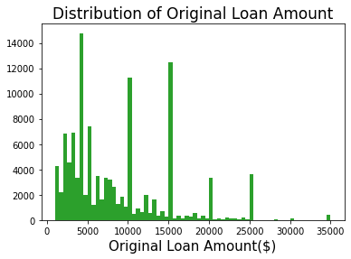

```python
# Standard histogram of the "Loan Original Amount"
bins= np.arange(1000,35000+500,500)
base_color= sns.color_palette()[2]
plt.hist(data=loan_clean, x= 'LoanOriginalAmount', bins=bins, color= base_color)
plot_label('Distribution of Original Loan Amount', 'Original Loan Amount($)', "")

plt.show();
```

> The plot appears to have irregular spikes and with a long-tailed distribution of data in the upper region of the values. Let's try plotting this on a log10 scale.

```python
np.log10(loan_clean['LoanOriginalAmount'].describe())
```

```
count    5.056665
mean     3.921011
std      3.795588
min      3.000000
25%      3.602060
50%      3.812913
75%      4.079181
max      4.544068
Name: LoanOriginalAmount, dtype: float64
```

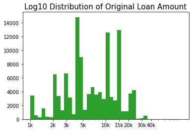

```python
# Histogram of Loan original Amount on a Log scale
bins= 10 ** np.arange(3, 5+ 0.05, 0.05)
ticks= [1000,2000,3000,5000, 10000,15000,20000,30000, 40000]
#plt.figure(figsize=[8,5])
labels = ['1k','2k','3k', '5k', '10k','15k','20k','30k', '40k']
base_color= sns.color_palette()[2]
plt.hist(data=loan_clean,x= 'LoanOriginalAmount', bins= bins, color= base_color);
plt.title('Log10 Distribution of Original Loan Amount', font={'size':15})
plt.xscale('log');
plt.xticks(ticks,labels);
```

After a log transform, the histogram of Loan Original amount shows lower number of loans on the lower end. There is a spike just before 5k dollars, 10k dollars and 15k dollars.

### What is the distribution of the Interest Rates?

#### A histogram will be plotted to see the distribution of this variable among the loans listed/originated.

```python
# Convert the "BorrowerRate" column into standard representation of percentage to allow a more meaningful interpretation
loan_clean['BorrowerRate (%)']= loan_clean['BorrowerRate']*100
# Round the values to a 2 decimal place to make easier to read
loan_clean['BorrowerRate (%)']= loan_clean.loc[:,'BorrowerRate (%)' ].round(2)
```

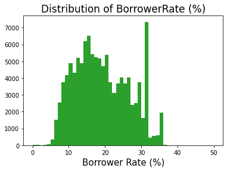

```python
# Set a convenient bin for the histplot
base_color= sns.color_palette()[2]
bins= np.arange(0,50+1,1)
plt.hist(data=loan_clean, x= 'BorrowerRate (%)', bins=bins, color=base_color)
plot_label('Distribution of BorrowerRate (%)', 'Borrower Rate (%)', "")
plt.show();
```

The borrower's rate show an almost normal distribution with a steady increase in the interest rate from about 5-20% with a lot of loans falling in this region. There is an observed fall in the frequency of loans in the upper range of interest rate, although, there appears to be a spike in the frequency of loans a little above the 35% interest rate.

```python
sns.color_palette()
```

```python
loan_percent=loan_clean['LoanStatus'].value_counts()/loan_clean['LoanStatus'].shape[0] *100
loan_percent
```

```
Current                   49.655511
Completed                 33.416713
Chargedoff                10.525115
Defaulted                  4.404188
Past Due (1-15 days)       0.707408
Past Due (31-60 days)      0.318597
Past Due (61-90 days)      0.274713
Past Due (91-120 days)     0.266814
Past Due (16-30 days)      0.232585
FinalPaymentInProgress     0.179924
Past Due (>120 days)       0.014043
Cancelled                  0.004388
Name: LoanStatus, dtype: float64
```

### What is the Distribution of Loan Status across the dataset?

```python
type_count= loan_clean['LoanStatus'].value_counts()
# gets sum of all non-null values
n_loan=loan_clean['LoanStatus'].value_counts().sum()
```

```
Percentage of Chargedoff loans: 10.5%
Total percentage of Bad loans: 16.6%
```

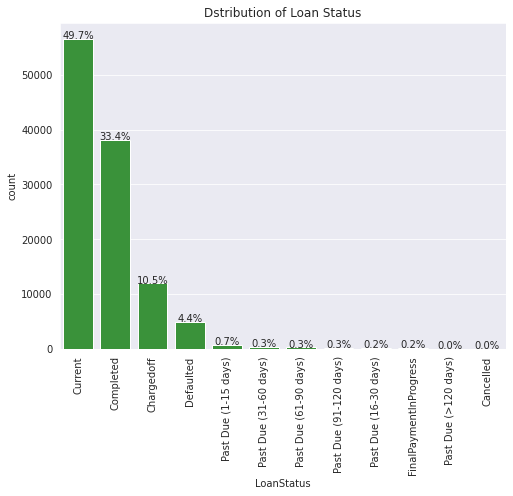

```python
print('Percentage of Chargedoff loans: 10.5%' )
print('Total percentage of Bad loans: 16.6%')
# Set figure axes and plot graph
plt.figure(figsize=[8,6])
sns.set_style('darkgrid')
loan_order= loan_clean['LoanStatus'].value_counts().sort_values(ascending=False).index
base_color= sns.color_palette()[2]
sns.countplot(data=loan_clean, x='LoanStatus', order= loan_order, color=base_color)
plt.title('Dstribution of Loan Status')

loc, labels = plt.xticks(rotation='vertical')

# Loop through each pair of location and labels
for loc, labels in zip(loc,labels):
    count=type_count[labels.get_text()]
    pct_string='{:0.1f}%'.format(100*count/n_loan)
    plt.text(loc, count+2, pct_string, ha='center')
#
plt.show()
```

A large percentage (~50%) of the loans are still active (current), but we can see that more than 10% of the entire loans listed over the years have been classified as being **chargedoff**. We also see that 16.6% of the loans ever listed are bad loans. This proportion is significant and worth investigating.

### What does the Prosper Rating and Prosper Score look like across the dataset?

**I will create two countplots to understand the distribution of these variables**

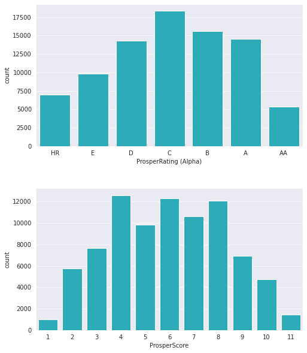

```python
    # Creates a figure to place the two plots
fig, ax = plt.subplots(nrows=2, figsize = [8,10])
plt.subplots_adjust(hspace=0.3)   # necessary to put enough vertical space between the two plots
color= sns.color_palette()[9]
sns.countplot(data= loan_clean, x= 'ProsperRating (Alpha)', color= color, ax=ax[0])
sns.countplot(data= loan_clean, x= 'ProsperScore', color=color, ax=ax[1])
```

The Prosper rating represents the level of risks associated with a loan, with HR and AA representing highest and lowest risk respectively. In the plot above, we can see that there is a step-like increase in the loans with poor Prosper Ratings (HR - D). The highest number of Prosper loans have a Prosper rating of **C**, implies that the majority of the loans only needed to have an average **C** rating. Interestingly, loans with better Prosper ratings (B - AA) are fewer, with AA loans being the lowest.

The Prosper score also estimates how a good a loan is, with 11 having lowest risk and 1 having highest risk. The distribution among these scores is very similar to the Prosper score rating. Loans with a prosper score of 4, 6, and 8 have the highest frequency, with a slight difference them.

### What is the distribution of Loans across the term?

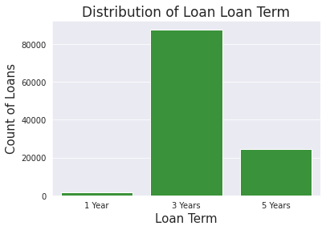

```python
# term_count= loan_clean['Term'].value_counts()
# n_term= loan_clean['Term'].value_counts().sum()
ax=sns.countplot(data=loan_clean, x= 'Term', color=base_color)
ticks=[12,36,60]
labels=['1 Year', '3 Years','5 Years']
ax.set_xticklabels(labels)
plot_label('Distribution of Loan Loan Term', 'Loan Term', 'Count of Loans')

# loc, labels = plt.xticks(rotation='vertical')

# # Loop through each pair of location and labels
# for loc, labels in zip(loc,labels):
#     count=term_count[labels.get_text()]
#     # convert lo
#     pct_string='{:0.1f}%'.format(100*count/n_loan)
#     plt.text(loc, count+2, pct_string, ha='center')
```

As presented in the graph above, over 80,000 of the loans originated are slated to last for a period of 3 years. Loans with years validity are slightly above 20,000.

### What is the Distribution of Borrowers' stated Monthly Income?

```python
# Convert the monthly income column to integer
loan_clean['StatedMonthlyIncome']= loan_clean['StatedMonthlyIncome'].round().astype(int)
loan_clean['StatedMonthlyIncome'].describe().apply(lambda x: format(x, 'f')) #to see the statistical summary of the column in nom-standard formn
```

```
count     113937.000000
mean        5608.027542
std         7478.497489
min            0.000000
25%         3200.000000
50%         4667.000000
75%         6825.000000
max      1750003.000000
Name: StatedMonthlyIncome, dtype: object
```

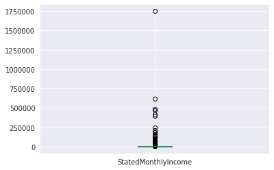

```python
# Plot a boxplot to see distribution of values in the column
loan_clean['StatedMonthlyIncome'].plot(kind='box')
plt.ticklabel_format(style='plain', axis='y')
```

The **StatedMonthlyIncome** column seem to have too many outliers with an even extreme one around 1.7 million dollars. These outliers seem too much an amount that can be earn monthly and since these outliers greatly affect the overall distribution of the data, loans with these outliers will eventually be removed in future analysis involving this variable,

Lst's further look into this variable using a histogram

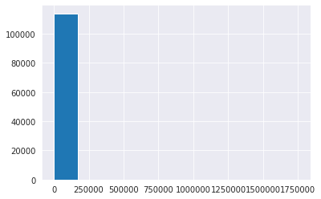

```python
# Sets the bins and plot the histogram
bins= np.arange(0, loan_clean['StatedMonthlyIncome'].max()+200, 200)
plt.hist(data= loan_clean, x= 'StatedMonthlyIncome')

plt.ticklabel_format(style='plain')
```

The above histogram will be plotted on a log scale to better see the distribution of income below 25k

```python
# gets the summary statistics on a log10 base
np.log10(loan_clean['StatedMonthlyIncome'].describe())
```

```
count    5.056665
mean     3.748810
std      3.873814
min          -inf
25%      3.505150
50%      3.669038
75%      3.834103
max      6.243039
Name: StatedMonthlyIncome, dtype: float64
```

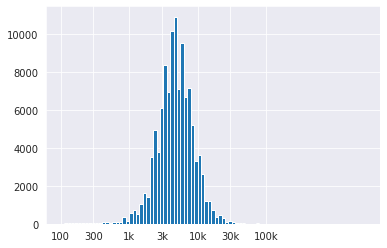

```python
# Sets bin and plot histogram
bins= 10** np.arange(2, 6.5, 0.05) # 10 raised to the power of the bin to display the natural number of each xtick
plt.hist(data= loan_clean, x= 'StatedMonthlyIncome', bins=bins)
ticks=[100,300,1000,3000,10000,30000,100000]
labels=['100','300','1k', '3k','10k','30k','100k']

plt.xscale('log')
plt.xticks(ticks, labels);
```

The distribution of the stated monthly income plotted on a log scale shows a unimodal distribution. Most of the borrowers have earn between 3,000 to 10,000 dollars monthly with regular frequency spikes across this range. Fewer number of borrowers earn below 3,000 dollars and above 10,000 dollars respectively.

```python
# length of extreme outliers to be dropped
len(loan_clean.query('StatedMonthlyIncome > 30000'))
```

```
327
```

```python
# Filter dataframe by Monthly income less than $30,000
loan_clean= loan_clean.query('StatedMonthlyIncome <= 30000')
```

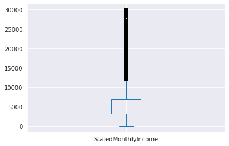

```python
loan_clean['StatedMonthlyIncome'].plot(kind='box')
```

```python
loan_clean['StatedMonthlyIncome'].describe()
```

```
count    113610.000000
mean       5453.107587
std        3508.812041
min           0.000000
25%        3197.000000
50%        4667.000000
75%        6750.000000
max       30000.000000
Name: StatedMonthlyIncome, dtype: float64
```

### What is the distribution of Listing Category?

```python
type_count= loan_clean['ListingCategory (numeric)'].value_counts()
type_count
#n_category= type_count.sum()
```

```
1     58170
0     16915
7     10467
2      7391
3      7152
6      2571
4      2390
13     1993
15     1519
14      876
18      874
20      766
19      765
5       756
16      303
11      217
8       198
10       91
9        85
12       59
17       52
Name: ListingCategory (numeric), dtype: int64
```

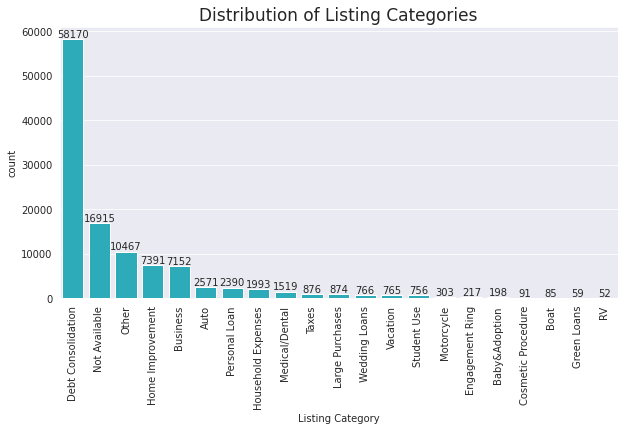

```python
import matplotlib.pyplot as plt
# Order the categories in descending order to make visual more appealing
ordered_loan= loan_clean['ListingCategory (numeric)'].value_counts().sort_values(ascending=False).index
base_color= sns.color_palette()[9]
plt.figure(figsize=[10,5])
ax=sns.countplot(data=loan_clean, x= 'ListingCategory (numeric)', order= ordered_loan, color=base_color)
# set xticks
ticks=[0,1,2,3,4,5,6,7,8,9,10,11,12,13,14,15,16,17,18,19,20]

# Correctly set tick labels to ensure each bar is represented correctly
labels=[ 'Debt Consolidation','Not Available', 'Other', 'Home Improvement', 'Business', 'Auto', 'Personal Loan', 'Household Expenses',
      'Medical/Dental', 'Taxes', 'Large Purchases', 'Wedding Loans', 'Vacation', 'Student Use', 'Motorcycle', 'Engagement Ring', 'Baby&Adoption',
       'Cosmetic Procedure', 'Boat', 'Green Loans', 'RV']
plt.title('Distribution of Listing Categories', font={'size':17})
plt.xlabel('Listing Category')
plt.xticks(ticks, labels, rotation=90)


abs_values=loan_clean['ListingCategory (numeric)'].value_counts().sort_values(ascending=False)
ax.bar_label(container=ax.containers[0], labels=abs_values)

# for i in range(type_count.shape[0]):
#     count= type_count[i]
#     plt.text(i, count+300,count, ha='center', va='bottom')

# locs, labels = plt.xticks(rotation= 90)
# for loc, label in zip(locs, labels):
#     count= type_count[label.get_text()]
#     pct_string= '{:.01f}%'.format(100*count/n_category)
#     plt.text(loc, count+2, pct_string, ha='center')
plt.show()
```

From the graphical information displayed (directly) above, we see that the largest proportion of the borrowers borrow for the purpose of consolidating debts. This makes me curious to want to further investigate the impact of this listing category on the loan outcome. About 17,000 borrowers did not provide reasons for taking the loan, while ~10,500 borrowers take their loan for other reasons not directly listed.

### What is the distribution of the Loan Listing Among the States?

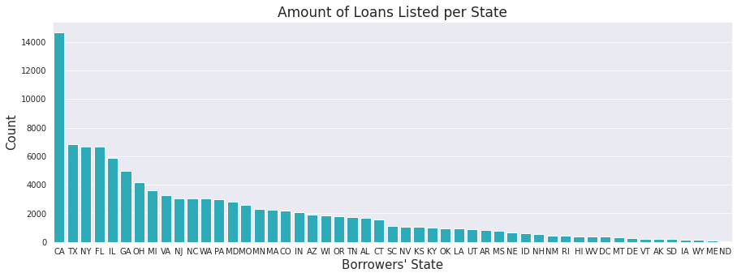

```python
type_count= loan_clean['BorrowerState'].value_counts().sort_values(ascending= False)
# set order of the bars
ordered= type_count.index
plt.figure(figsize=[15,5])
sns.countplot(data= loan_clean, x='BorrowerState', order= ordered, color = sns.color_palette()[9])
# Specify axis labels, titles,and ticks
plt.title('Amount of Loans Listed per State', font={'size':17})
plt.ylabel('Count', font={'size':15})
plt.xlabel("Borrowers' State", font={'size':15})
plt.xticks(rotation='horizontal')
# Show graph
plt.show()
```

The above graph clearly shows that amongst the 51 states where the borrowers come from, CA recorded the highest number of loans followed by Texas, New York, Florida, Illinios all of which recorded nearly the same amount of loans.

#### Now let's zoom into the top 10 states with the highest Loan Listing?

```python
type_count= loan_clean['BorrowerState'].value_counts().sort_values(ascending= False).head(10)
# gets sum of all non-null values
n_loan1=loan_clean['BorrowerState'].value_counts().sort_values(ascending= False).sum()
```

```python
type_count.sum()/n_loan1 *100
```

```
55.41424250552662
```

```python
n_loan1
```

```
108113
```

```
Percentage of loan listed by the top10 states = 55.4%
```

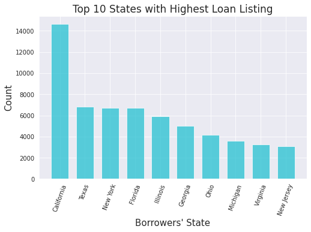

```python
# Prints percentage loan by the top10 states
print('Percentage of loan listed by the top10 states = {:.1f}%'.format(type_count.sum()/n_loan1 *100))
location= type_count.index
heights= type_count
plt.figure(figsize=[8,5])
ax=plt.bar(location, heights, color=base_color, width= .7, alpha=0.7)
plt.title('Top 10 States with Highest Loan Listing', font={'size':17})
plt.ylabel('Count', font={'size':15})
plt.xlabel("Borrowers' State", font={'size':15})
plt.xticks(rotation=70)
fig.canvas.draw()
plt.xticks(ticks=['CA','TX', 'NY', 'FL', 'IL', 'GA','OH', 'MI', 'VA', 'NJ'], labels=['California', 'Texas', 'New York', 'Florida', 'Illinois', 'Georgia', 'Ohio', 'Michigan', 'Virginia', 'New Jersey'])
# Show graph
plt.show()
```

### What is the income range distribution of the borrowers?

```python
loan_clean['IncomeRange'].value_counts()
```

```
$25,000-49,999    32192
$50,000-74,999    31049
$100,000+         17035
$75,000-99,999    16915
Not displayed      7718
$1-24,999          7274
Not employed        806
$0                  621
Name: IncomeRange, dtype: int64
```

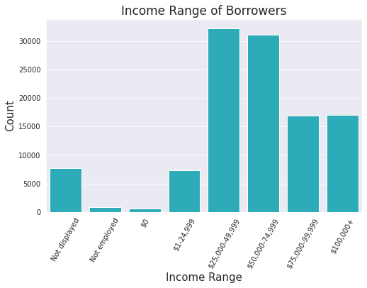

```python
plt.figure(figsize=[8,5])
sns.countplot(data= loan_clean, x= 'IncomeRange', color= base_color)

plt.title('Income Range of Borrowers', font={'size':17})
plt.ylabel('Count', font={'size':15})
plt.xlabel("Income Range", font={'size':15})
plt.xticks(rotation='60')

# show graph
plt.show()
```

The graph (directly) above shows that the income range of **32,192** and **31,050** borrowers falls in-between the 25,000 - 49,999 and 50,000-74,000 dollar range repectively. It can also be seen that borrowers with an income > $100,000 are more than the remaining categories.

### What is the distribution of Borrower's Employment Status?

```python
ordered=loan_clean['EmploymentStatus'].value_counts().sort_values(ascending=False).index # will order the chart' bars
status_count= loan_clean['EmploymentStatus'].value_counts().sort_values(ascending=False) # will be used while creating the bar labels
n_loan=loan_clean['EmploymentStatus'].value_counts().sum() # returns the sum of the value_counts
```

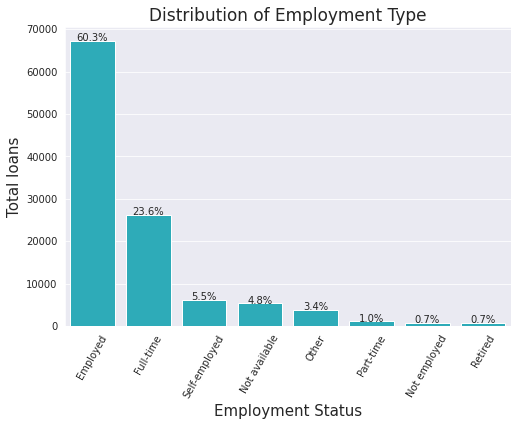

```python
# Set figure axes and plot chart
plt.figure(figsize=[8,5.5])
sns.countplot(data= loan_clean, x= 'EmploymentStatus', order=ordered, color= base_color)
loc,labels= plt.xticks(rotation=60)
# Loop through each pair of location and labels
for loc, labels in zip(loc,labels):
    count=status_count[labels.get_text()]
    # convert labels to percentage
    pct_string='{:0.1f}%'.format(100*count/n_loan)
    plt.text(loc, count+2, pct_string, ha='center')
# customised function will be used to label the chart
plot_label('Distribution of Employment Type','Employment Status','Total loans')
```

A massive 60% of the borrowers fall in the employed category. 23.6% are full time workers while 5.5% are self-employed. The observation from this chart helps us to know that 60% of the companies loans goes to people who are identified as **employed**. One implication of this is that majority of loan outcome is likely to be affected by this group of people.

### For how long have most of the borrowers been working/employed?

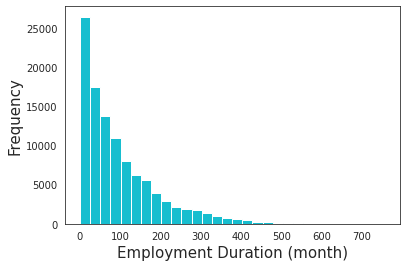

```python
# Create a dataframe with only finite values to avoid error when plotting histogram
finite_data=loan_clean[np.isfinite(loan_clean['EmploymentStatusDuration'])]
sns.set_style('white')
plt.hist(data=finite_data, x= 'EmploymentStatusDuration',color=base_color,bins=30);
plot_label('', 'Employment Duration (month)', 'Frequency')
```

The histogram of Employment duration above is greatly skewed to the right. Most of the borrowes have been employed for 0 to 100 months.

### How much loan is listed by yearly?

```python
# Extracts year column from List_Creation_Date
loan_clean['year']= loan_clean['ListingCreationDate'].dt.year
```

```python
# Set "year" column to be a categorical variable
ordered_years=[2005,2006,2007,2008,2009,2010,2011,2012,2013,2014]
order1= pd.api.types.CategoricalDtype(ordered=True, categories= ordered_years)
loan_clean['year'] = loan_clean['year'].astype(order1)
```

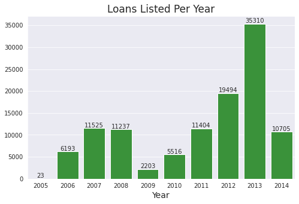

```python
# Set figure axes and plot chart
sns.set_style('darkgrid')
plt.figure(figsize=[8,5])
ax= sns.countplot(data= loan_clean, x= 'year', color= sns.color_palette()[2])

# store absolute values in a variable and configure the labels
abs_value1=loan_clean['year'].value_counts().to_frame().reset_index(drop=False).sort_values(by='index')
ax.bar_label(container=ax.containers[0], label= abs_value1)

# Set labels and ticks
plt.title('Loans Listed Per Year', font={'size': 17})
plt.xlabel( 'Year', font={'size': 14})
plt.ylabel('')
```

*Define a function to allow convenient chart formatting*

```python
def plt_label(t,y):
    title=plt.title(t,font={'size':15})
    ylabel=plt.ylabel(y, font={'size':11})
    return title, ylabel
```

### What is the quantity of loans listed across quarters and months of the years?

```python
# Extract months into a new column
loan_clean['Month']= loan_clean['ListingCreationDate'].dt.month

# This is needed to order the graph accordingly
order=loan_clean.groupby(['LoanOriginationQuarter']).count().Term.index
```

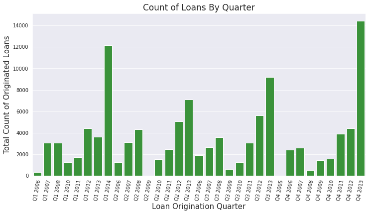

```python
# Set figure axes and plot graph
plt.figure(figsize=[12,6])
sns.set_style('darkgrid')
sns.countplot(data= loan_clean, x='LoanOriginationQuarter', order=order, color=sns.color_palette()[2]);
plt.xticks(rotation=80);
plot_label('Count of Loans By Quarter','Loan Origination Quarter','Total Count of Originated Loans')
```

**Now lets take a deeper dive to see how much loans have been given out in each month of the year**

```python
loan_clean['Month'].value_counts()
```

```
1     11183
10    10500
12    10285
2     10097
9     10049
11     9923
7      9481
8      9178
6      8642
5      8622
3      8014
4      7636
Name: Month, dtype: int64
```

```python
# Filter dataframe by each year
year2005= loan_clean.query('year == 2005')
year2006= loan_clean.query('year == 2006')
year2007= loan_clean.query('year == 2007')
year2008= loan_clean.query('year == 2008')
year2009= loan_clean.query('year == 2009')
year2010= loan_clean.query('year == 2010')
year2011= loan_clean.query('year == 2011')
year2012= loan_clean.query('year == 2012')
year2013= loan_clean.query('year == 2013')
year2014= loan_clean.query('year == 2014')
```

```
(Text(0.5, 1.0, 'Loans for Year 2014'), Text(0, 0.5, 'Count of Loans'))
```

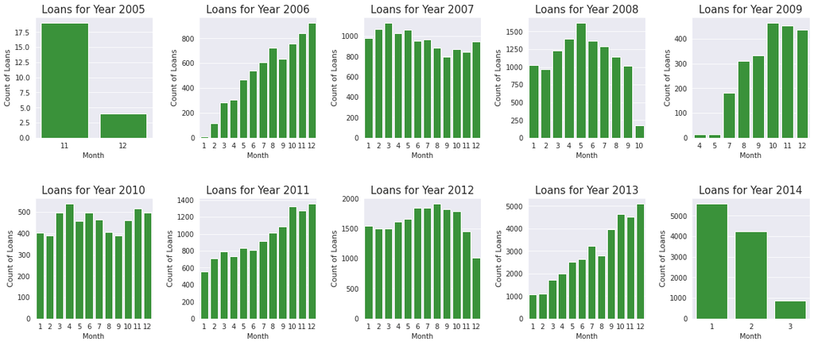

```python
# Code to plot the graph
fig, ax= plt.subplots(2,5, figsize=[20,8])
# Set Prosper spacing between each plots
plt.subplots_adjust(wspace=0.4)
plt.subplots_adjust(hspace=0.5)
base_color= sns.color_palette()[2]
# Plot each subplots
plt.subplot(2,5,1)
sns.countplot(data= year2005, x='Month', color=base_color )
plt_label('Loans for Year 2005','Count of Loans' )

plt.subplot(2,5,2)
sns.countplot(data= year2006, x='Month', color=base_color)
plt_label('Loans for Year 2006','Count of Loans' )

plt.subplot(2,5,3)
sns.countplot(data= year2007, x='Month', color=base_color)
plt_label('Loans for Year 2007','Count of Loans' )

plt.subplot(2,5,4)
sns.countplot(data= year2008, x='Month', color=base_color)
plt_label('Loans for Year 2008','Count of Loans' )

plt.subplot(2,5,5)
sns.countplot(data= year2009, x='Month', color=base_color)
plt_label('Loans for Year 2009','Count of Loans' )

plt.subplot(2,5,6)
sns.countplot(data= year2010, x='Month', color=base_color)
plt_label('Loans for Year 2010','Count of Loans' )

plt.subplot(2,5,7)
sns.countplot(data= year2011, x='Month', color=base_color)
plt_label('Loans for Year 2011','Count of Loans' )

plt.subplot(2,5,8)
sns.countplot(data= year2012, x='Month', color=base_color)
plt_label('Loans for Year 2012','Count of Loans' )

plt.subplot(2,5,9)
sns.countplot(data= year2013, x='Month', color=base_color)
plt_label('Loans for Year 2013','Count of Loans' )

plt.subplot(2,5,10)
sns.countplot(data= year2014, x='Month', color=base_color)
plt_label('Loans for Year 2014','Count of Loans' )
```

The chart of loans listing by month does not seem to show a significant relationship across the years. However, we can observe an upward trend in the amount of loans in the year 2006, 2009, 2011, and 2013. There is however, a downward trend in the first quarter of year 2014.

### What is the distribution of bad loans across the years?

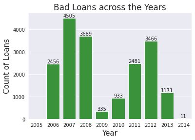

```python
# Filter original dataframe to give bad loans
bad_loans=loan_clean.query('LoanStatus != "Completed" & LoanStatus != "Current" & LoanStatus != "FinalPaymentInProgress"').reset_index(drop=True) # reset_index to avaoid possible problem with
ax=sns.countplot(data=bad_loans, x= 'year', color=base_color)

abs_label= bad_loans['year'].value_counts().to_frame().reset_index(drop=False).sort_values(by='index')
ax.bar_label(container=ax.containers[0], label=abs_label)
# Set labels using custom function
plot_label('Bad Loans across the Years', 'Year', 'Count of Loans')
```

We can see from the above chart, that by 2006, the firm was already having almost 2500 bad loans. This value rose to over 4000 by 2007 and dropped significantly in 2009. Bad loans again increased through 2012. However, 2013 saw a significant decrease in the number of bad loans.

### What is the Distribution of Group Status Among Borrowers?

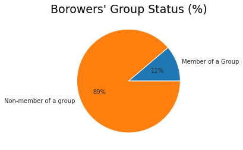

```python
x= loan_clean['CurrentlyInGroup'].value_counts().sort_values(ascending=True)
plt.pie(x, labels=['Member of a Group','Non-member of a group'], autopct='%1.0f%%');
plt.title("Borowers' Group Status (%)", font={'size':19}, color='black')
plt.xticks()

plt.show()
```

The pie chart above shows that there is a significantly higher proportion of borrowers who do not belong to a group compared to those who belong to a group.

### Of the features you investigated, were there any unusual distributions? Did you perform any operations on the data to tidy, adjust, or change the form of the data? If so, why did you do this?

> When investigating the Borrowers monthly income, I discovered sevral extreme outliers. Data points of these outliers of about 340 had to be removed from the dataset. One interrsting observation also was that the first 3 months of 2014 had already received loan listings higher than that any other quarter of the previous years, except Q4 of 2013.

## Bivariate Exploration

### How does the Loan Original Amount relate to the Interest rate?

```
loan clean.shape= (113610, 84)
loan_clean_sample.shape= (11000, 84)
```

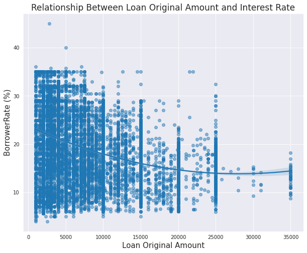

```python
print('loan clean.shape=', loan_clean.shape)
loan_clean_sample= loan_clean.sample(n=11000, replace= False) # Create a random sample data of n=11000 to make plot easy to understand
print('loan_clean_sample.shape=', loan_clean_sample.shape)

plt.figure(figsize=[10,8])

sns.regplot(data= loan_clean_sample, y='BorrowerRate (%)', x= 'LoanOriginalAmount', x_jitter=0.3, order=2,scatter_kws={'alpha':0.5})
plot_label('Relationship Between Loan Original Amount and Interest Rate', 'Loan Original Amount', 'BorrowerRate (%)')
```

The scatterplot above shows a somewhat curved, but negative relationship between the Loan original amount and Interest rate. Larger loan amounts are seen to have lower interest rate, while lower loan amounts have higher interest rates. We can also see that most of the loans originated are between 0-$15,000 range, and are clustered between around the 5% to 35% interest rate.

### What is the Relationship Between Loan Outcome and Loan Original Amount?

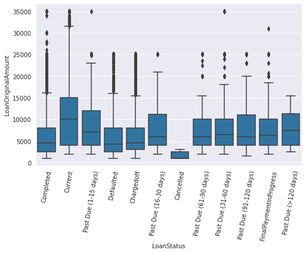

```python
# set figure axes and plot chart
plt.figure(figsize=[8,5])

sns.set_style('darkgrid')
sns.boxplot(data=loan_clean, x='LoanStatus', y='LoanOriginalAmount', color=sns.color_palette()[0])
plt.xticks(rotation=80);
```

There seem to be little interaction between the loan status and loan original amount, especially since there is a relatively lower proportion of loans that were either cancelled, past due, or payment-in-progress.

### What is the Relationship Between Loan Outcome and Interest Rate (%)?

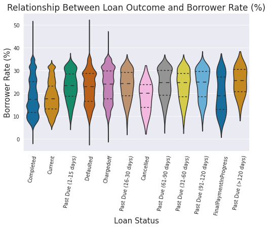

```python
sns.set_style('darkgrid')
plt.figure(figsize=[8,5])
sns.violinplot(data = loan_clean, x='LoanStatus', y='BorrowerRate (%)', palette='colorblind', inner='quartile');
plt.xticks(rotation=80);
plot_label('Relationship Between Loan Outcome and Borrower Rate (%)', 'Loan Status', 'Borrower Rate (%)')
```

The median of the all bad loans(defaulted, chargedoff, and pastdue) are higher than those of either the completed or current loans. We can also see that most of the completed loans have lower interest rates, compared to the defaulted and chargedoff loans. This suggests that a loan is likely to turn out bad if the interest rate is on the high side.

### What is the distribution of Interest rate for each Loan term?

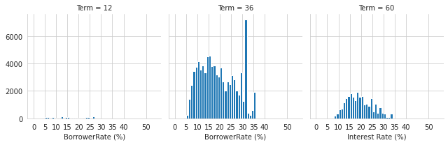

```python
sns.set_style('whitegrid')
bins=np.arange(0, 55, 1)
g=sns.FacetGrid(data= loan_clean, col='Term')
g.map(plt.hist, 'BorrowerRate (%)', bins=bins)
ticks=[0,5,10, 15,20,25,30,35,40,50]
plt.xticks(ticks);
plt.xlabel('Interest Rate (%)')
```

### How much worth of loans do we give out yearly?

```python
year_amount=loan_clean.groupby(['year'], as_index=False).LoanOriginalAmount.sum()
year_amount
```

|  | year | LoanOriginalAmount |
| --- | --- | --- |
| 0 | 2005 | 88687 |
| 1 | 2006 | 29883889 |
| 2 | 2007 | 81226927 |
| 3 | 2008 | 66811724 |
| 4 | 2009 | 9665013 |
| 5 | 2010 | 26665382 |
| 6 | 2011 | 76286201 |
| 7 | 2012 | 153221488 |
| 8 | 2013 | 373763754 |
| 9 | 2014 | 127260665 |

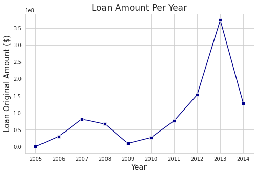

```python
# Set figure axes and plot visuals
plt.figure(figsize=[8,5])
sns.set_style('whitegrid')
ax=sns.lineplot(data= year_amount, x= 'year', y= 'LoanOriginalAmount',marker='s', color='darkblue')
plt.xticks(ticks=[2005,2006,2007,2008,2009,2010,2011,2012,2013,2014])
plot_label('Loan Amount Per Year', 'Year', 'Loan Original Amount ($)')

labels=['0', '50 mil', '100 mil', '150 mil', '200 mil', '250 mil', '300 mil', '350 mil']
#ax.set_yticklabels(labels)

plt.show();
```

### What have been the Status of Loans Over the years?

[figure not shown]

```python
plt.figure(figsize=[12,7])
sns.countplot(data=loan_clean, x='year', hue='LoanStatus', palette='colorblind')

plt.xticks(rotation=0);
plt.tight_layout()
plt.legend(loc='upper center', title='Loan Status', labels=['Completed', 'Past Due (1-15 days)', 'Defaulted', 'Chargedoff',
                                                          'Past Due (16-30 days)', 'Cancelled','Past Due (2-3 months)', 'Past Due (1-2 months)', 'Past Due (3-4 months)',
                                                           'Final Payment in Progress','Past Due (>4 months)'])
```

### How successful is the Prosper Rating in preventing Bad loans?

```python
not_current= loan_clean.query('LoanStatus != "Current"')
```

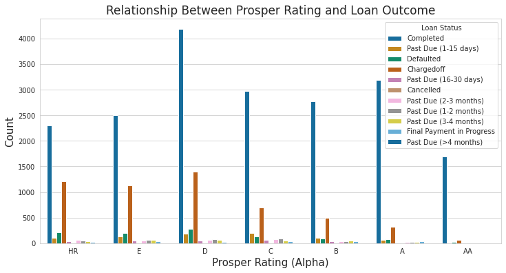

```python
# Set figure axes and plot visuals
plt.figure(figsize=[12,6])
sns.countplot(data=not_current, x='ProsperRating (Alpha)', hue='LoanStatus', palette='colorblind')
plt.title('Relationship Between Prosper Rating and Loan Outcome', font={'size':17})
plt.xlabel('Prosper Rating (Alpha)', font={'size':15})
plt.ylabel('Count', font={'size':15})
plt.legend(loc='upper right', title='Loan Status', labels=['Completed', 'Past Due (1-15 days)', 'Defaulted', 'Chargedoff',
                                                          'Past Due (16-30 days)', 'Cancelled','Past Due (2-3 months)', 'Past Due (1-2 months)', 'Past Due (3-4 months)',
                                                           'Final Payment in Progress','Past Due (>4 months)'])
```

The above plot shows that across all the seven possible ratings, **completed loans** take the highest count. However surprising is the fact that loans rated **D** appear to have the highest count of **completed and chargedoff loans**. We can also see a relatively high number of **chargedoff** loans across all ratings, which reduces significantly moving from **D (highest chargedoff loans)** to **AA** loans. Defaullted, Cancelled and Past due loans also reduce as the Prosper rating increases

### What is the relationship between Loan status and Employment Duration?

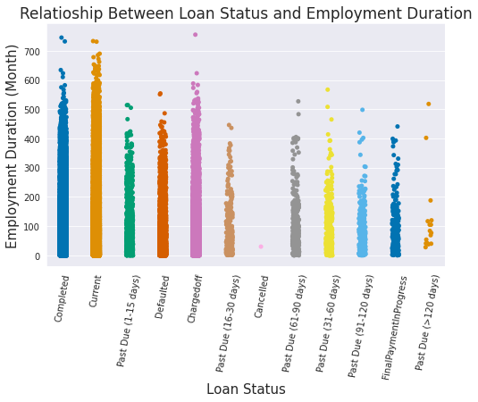

```python
# Set convenient figure axes and plot visual
sns.set_style('darkgrid')
plt.figure(figsize=[8,5])
sns.stripplot(data = loan_clean, x= 'LoanStatus', y= 'EmploymentStatusDuration', palette='colorblind');
plt.xticks(rotation=80);

# set labels and titl using custom function
plot_label('Relatioship Between Loan Status and Employment Duration', 'Loan Status', 'Employment Duration (Month)')
```

### What is the relationship between Prosper rating and Investors?

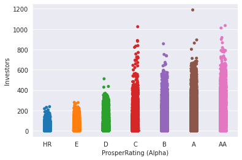

```python
sns.stripplot(data= loan_clean, x='ProsperRating (Alpha)', y= 'Investors')
```

### What is the relationship Between Loan Status and Being in a Group?

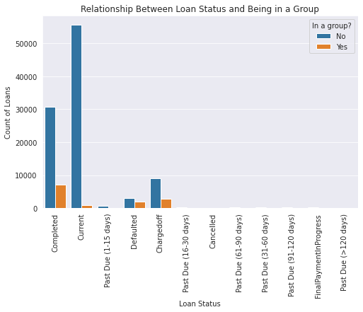

```python
sns.set_style('darkgrid')
# Code to set Figure axes and plot graph
plt.figure(figsize=[8,5])
sns.countplot(data=loan_clean, x='LoanStatus', hue='CurrentlyInGroup');
plt.xticks(rotation=90);
plt.title('Relationship Between Loan Status and Being in a Group')
plt.xlabel('Loan Status')
plt.ylabel('Count of Loans')
plt.legend(title='In a group?', labels=['No', 'Yes']);
```

### What is the relationship between Loan Status and Term for Bad Loans?

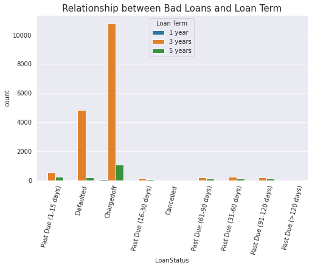

```python
# Filter original dataframe to give bad loans
bad_loans=loan_clean.query('LoanStatus != "Completed" & LoanStatus != "Current" & LoanStatus != "FinalPaymentInProgress"').reset_index(drop=True) # reset_index to avaoid possible problem with
sns.set_style('darkgrid')                                                                                                     # handling rows
# Code to set Figure axes and plot graph
plt.figure(figsize=[8,5])
sns.countplot(data= bad_loans, x='LoanStatus', hue='Term');
plt.xticks(rotation=76);
plt.title('Relationship between Bad Loans and Loan Term', font={'size':15})
plt.legend(title='Loan Term', loc='upper center', labels=['1 year', '3 years', '5 years']);
```

As expected, one can see from the chart above that there is a high amount of bad loans for loans slated to last for 3 years across the chart. This is evident especially for the chargedoff loans. Loan term therefore seem to affect the outcome of loans.

### What is the relationship between Employment status and Loan Outcome?

[figure not shown]

```python
sns.set_style('darkgrid')
# Set figure axes and plot visuals
plt.figure(figsize=[12,6])
sns.countplot(data=loan_clean, x='EmploymentStatus', hue='LoanStatus', palette='colorblind')
plt.title('Relationship Between Employment Status and Loan Outcome', font={'size':17})
plt.xlabel('Employment Status', font={'size':15})
plt.ylabel('Total Loans', font={'size':15})
plt.legend(loc='upper center', title='Loan Status', labels=['Completed', 'Past Due (1-15 days)', 'Defaulted', 'Chargedoff',
                                                          'Past Due (16-30 days)', 'Cancelled','Past Due (2-3 months)', 'Past Due (1-2 months)', 'Past Due (3-4 months)',
                                                           'Final Payment in Progress','Past Due (>4 months)'])
```

### What is the relationship Between Employment Status and Employment Status duration?

```python
loan_clean['EmploymentStatus'].value_counts()
```

```
Employed         67135
Full-time        26297
Self-employed     6076
Not available     5334
Other             3805
Part-time         1088
Not employed       835
Retired            794
Name: EmploymentStatus, dtype: int64
```

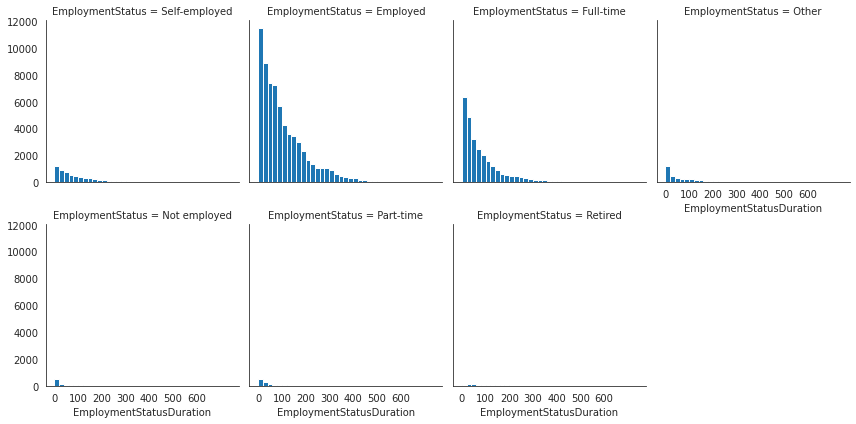

```python
# Non_null values are needed to avoid error
finite_data= loan_clean[np.isfinite(loan_clean['EmploymentStatusDuration'])]
''
# Set figure axis, customize background, and plot chart
sns.set_style('white')
bins=np.arange(0, finite_data['EmploymentStatusDuration'].max()+5,20 )
g=sns.FacetGrid(data= finite_data, col='EmploymentStatus', col_wrap=4)
g.map(plt.hist, 'EmploymentStatusDuration', bins=bins);
plt.xticks([0,100,200,300,400,500,600]);
```

The histograms above show that the bulk of the total loans listed falls in the *employed* category. The histogram of employment duration for the *employed* category reveals that most of the borrowers that are employed have been employed for 0 to 100 months.

### Did you observe any interesting relationships between the other features (not the main feature(s) of interest)?

> Investigating the relationship between some other variables, I discovered that more investors invest in loans with better rating. Most of the borrwers have been emoloyed for fewer nummber of years.

## Multivariate Exploration

### What is the Relationship Between Loan Original Amount, Borrower Rate and Monthly Income?

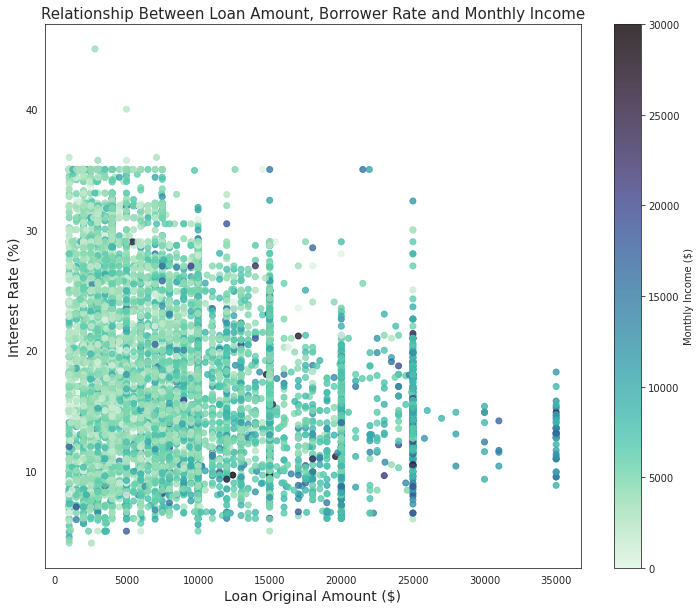

```python
# Use a 11000 sample of the loan_clean data to make it easy to plot visuals, and improve readability
plt.figure(figsize=[12,10])
plt.scatter(data= loan_clean_sample, x='LoanOriginalAmount', y = 'BorrowerRate (%)', c= 'StatedMonthlyIncome', alpha=0.8, cmap= 'mako_r');

plt.colorbar(label='Monthly Income ($)')
plt.title('Relationship Between Loan Amount, Borrower Rate and Monthly Income', font={'size': 15})
plt.xlabel('Loan Original Amount ($)', font={'size': 14})
plt.ylabel('Interest Rate (%)', font={'size': 14})
plt.show();
```

We can see that majority of the loans given to people who earn less than $10000 are on the lower end, and they are the ones who generally repay more (they get higher interest rates). This relationship may explain why there are more bad loans as interest rate increases.

### What is the relationship between loan amount and loan status based on loan term?

```python
Term12=loan_clean.query('Term == 12')
Term36=loan_clean.query('Term == 36')
Term60=loan_clean.query('Term == 60')
```

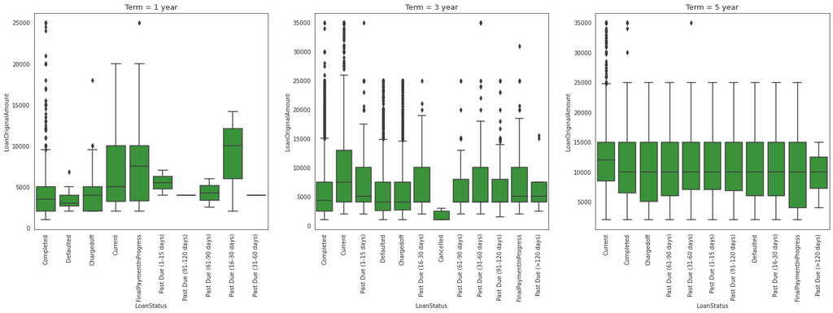

```python
fig, ax=plt.subplots(1,3, figsize=[25,7])
plt.subplot(1,3,1)
sns.boxplot(data=Term12, x='LoanStatus', y='LoanOriginalAmount',color=base_color)
plt.title('Term = 1 year', font={'size':13})
plt.xticks(rotation=90)
plt.subplot(1,3,2)
sns.boxplot(data=Term36, x= 'LoanStatus', y='LoanOriginalAmount', color=base_color)
plt.title('Term = 3 year', font={'size':13})
plt.xticks(rotation=90)
plt.subplot(1,3,3)
sns.boxplot(data=Term60, x='LoanStatus', y='LoanOriginalAmount', color=base_color)
plt.title('Term = 5 year', font={'size':13})
plt.xticks(rotation=90);
```

There is little relationship between the loan amount and loan status based on term. One can however observe that for 5 year loans, the median all the categories are almost the same.

### What is the relationship between loan amount and interest rate across term and loan status?

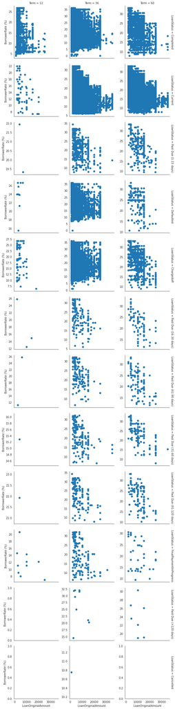

```python
plt.figure(figsize=[15,10])
g=sns.FacetGrid(data= finite_data, col= 'Term', row='LoanStatus', margin_titles=True,sharey=False)
g.map(plt.scatter, 'LoanOriginalAmount', 'BorrowerRate (%)')
```

The plot above looks really long, but one would notice a negative relationship for completed, current, defaulted and chargedoff loans for 36 and 60 months term loans. This relationship depletes moving towards past due loans.

### How does Loan amount relate with Loan Status Based on Loan Term?

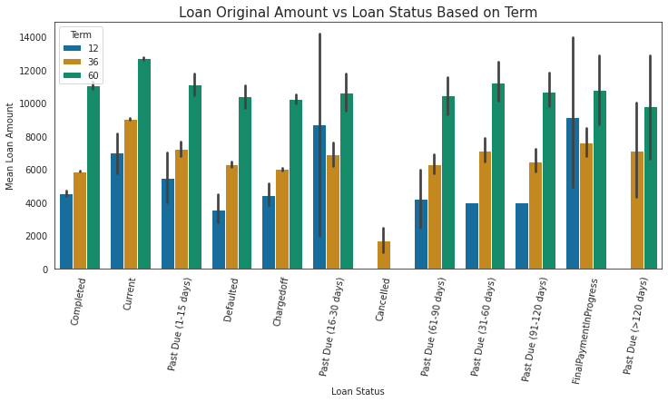

```python
# Code to set Figure axes and plot graph
plt.figure(figsize=[12,5])
sns.barplot(data=loan_clean, x='LoanStatus', y='LoanOriginalAmount',hue='Term', palette='colorblind')
plt.xticks(rotation=80);
plt.title('Loan Original Amount vs Loan Status Based on Term', font={'size':15})
plt.ylabel('Mean Loan Amount')
plt.xlabel('Loan Status')
#plt.legend(frameon=False, title='Loan Term', labels=['1 year', '3 years', '5 years']);
#plt.tight_layout();
```

### What is the relationship between Loan Outcome based on employment status and employment Duration

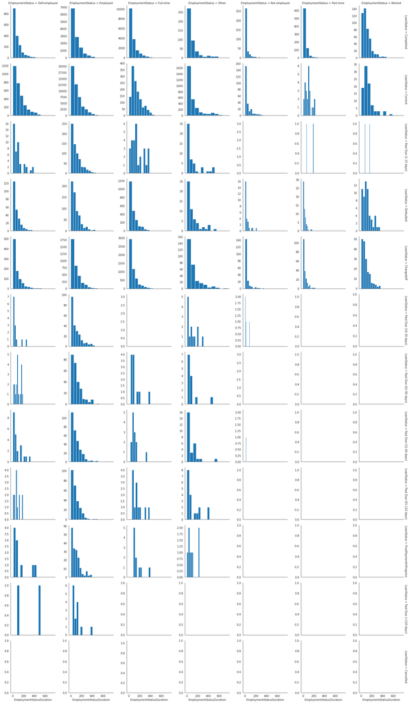

```python
g=sns.FacetGrid(data= finite_data, col='EmploymentStatus', row='LoanStatus',margin_titles=True,sharey=False)
g.map(plt.hist, 'EmploymentStatusDuration',bins=10)
```

For all possible loan outcomes, and across all the categries of employment, the employment duration is skewed to the right. I do not think that this relationship presents any worthy insight.

### Talk about some of the relationships you observed in this part of the investigation. Were there features that strengthened each other in terms of looking at your feature(s) of interest?

> I furthered my investigation between the loan amount and interest rate by looking at influence of borrowers' monthly income. This multivariate exploration revealed that majority of the loans given to people who earn less than $10000 are on the lower end, and they are the ones who generally repay more (they get higher interest rates). This relationship may explain why there are more bad loans as interest rate increases.

### Were there any interesting or surprising interactions between features?

> There were no surprising interactions between features, except that borrowers with lower monthly income are the one receiving lesser loan amount but paying more in interest.

## Conclusions

During exploration, I started by looking at the distribution of the loan original amounts and I found out that on a log transform, there are fewer lower number of loans on the lower end ( $1,000 - $4,000), but with spikes just before $5,000, $10,000 and $15,000. Looking into the interest rate, I realised that majority of the interest rate on loans are between 5% and 30%. I then looked into the laon status variable and I found out that ~50% of all the loans are still active, 30% had already completed their loans while 10% of the loans had been chargedoff. Also, I find it interesting that more half of the prosper loans were taken to by borrowers to consolidate their debts.

Of the 51 US states represented, the top10 states with the highest loan listing represented 55% of the entire loans listed. After investigating the amount of loans listed in each quarter of each year, I discovered that Q1 of 2014 had received more loan than any other quarter of the previous years, with the exception of Q4 of 2013.

Investigating the relationship between Loan Original Amount, Borrower Rate and Monthly Income, I realised that majority of the loans given to people who earn less than $10000 monthly are on the lower end, and they are the ones who generally repay more (they get higher interest rates). This relationship may explain why there are more bad loans as interest rate increases.

The variables most associated with the loan outcome are; interest rate, prosper ratings, and group status. All these variables act as factors that can influence a loan's outcome. Furthermore, interesr rate was found to be affected by the loan amount.

back to top